# Exercise prediction

Volodymyr Dovhanyk

Saturday, January 23, 2016

**Execution Summary** Based on data available from Jawbone Up, Nike FuelBand, and Fitbit random forest model was generated to predict activity type based on telemetry devices output.

**Data overview**

Using devices such as Jawbone Up, Nike FuelBand, and Fitbit it is now possible to collect a large amount of data about personal activity relatively inexpensively. These type of devices are part of the quantified self movement – a group of enthusiasts who take measurements about themselves regularly to improve their health, to find patterns in their behavior, or because they are tech geeks. One thing that people regularly do is quantify how much of a particular activity they do, but they rarely quantify how well they do it. In this project, your goal will be to use data from accelerometers on the belt, forearm, arm, and dumbell of 6 participants. They were asked to perform barbell lifts correctly and incorrectly in 5 different ways. Based on collected data we are going to predict participant activity.

```r
trainingGD<-read.csv("data/training.csv")
testing<-read.csv("data/testing.csv")
```

Using uploaded data and caret package we created two subsets from the training one - training and validation

```r
set.seed (321)
intrain<-createDataPartition (y=trainingGD$classe, p=.6, list=F)
training<-trainingGD[intrain,]
validation<-trainingGD[-intrain,]
```

Results of such kind of splinting is presented below

```
## [1] 11776   160
```

```
## [1] 7846  160
```

```
## [1]  20 160
```

On the first general view into the data we can not define the simple single classifier to determ the exercise class. Basic plots are listed below

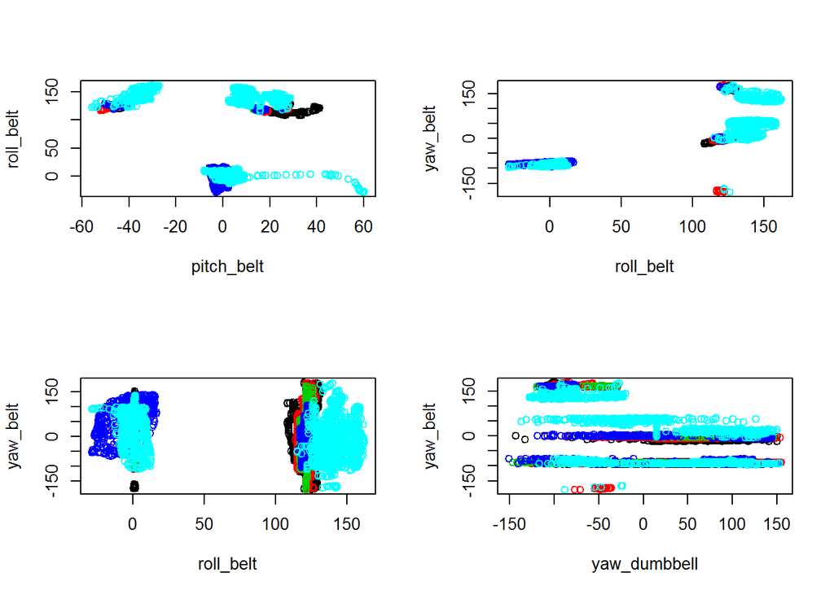

In training set we can find out that a lot of variables have mostly NA values. Variance evaluation enable us to make the decision about what variables should be conducted in the final model.

```r
nsv<-nearZeroVar(training, saveMetrics=TRUE)
nsv
```

```
##                             freqRatio percentUnique zeroVar   nzv
## X                            1.000000  100.00000000   FALSE FALSE
## user_name                    1.100469    0.05095109   FALSE FALSE
## raw_timestamp_part_1         1.076923    7.09918478   FALSE FALSE
## raw_timestamp_part_2         1.000000   90.83729620   FALSE FALSE
## cvtd_timestamp               1.014477    0.16983696   FALSE FALSE
## new_window                  45.916335    0.01698370   FALSE  TRUE
## num_window                   1.076923    7.26902174   FALSE FALSE
## roll_belt                    1.092937    8.57676630   FALSE FALSE
## pitch_belt                   1.103448   13.78226902   FALSE FALSE
## yaw_belt                     1.171429   14.47860054   FALSE FALSE
## total_accel_belt             1.059138    0.22927989   FALSE FALSE
## kurtosis_roll_belt        2305.000000    2.09748641   FALSE  TRUE
## kurtosis_picth_belt        606.578947    1.79177989   FALSE  TRUE
## kurtosis_yaw_belt           45.916335    0.01698370   FALSE  TRUE
## skewness_roll_belt        2881.250000    2.08899457   FALSE  TRUE
## skewness_roll_belt.1       606.578947    1.85122283   FALSE  TRUE
## skewness_yaw_belt           45.916335    0.01698370   FALSE  TRUE
## max_roll_belt                1.428571    1.23131793   FALSE FALSE
## max_picth_belt               1.465116    0.16134511   FALSE FALSE
## max_yaw_belt               501.086957    0.50951087   FALSE  TRUE
## min_roll_belt                1.125000    1.23131793   FALSE FALSE
## min_pitch_belt               2.114286    0.13586957   FALSE FALSE
## min_yaw_belt               501.086957    0.50951087   FALSE  TRUE
## amplitude_roll_belt          1.368421    0.89164402   FALSE FALSE
## amplitude_pitch_belt         3.317073    0.09341033   FALSE FALSE
## amplitude_yaw_belt          48.020833    0.03396739   FALSE  TRUE
## var_total_accel_belt         1.408163    0.35665761   FALSE FALSE
## avg_roll_belt                1.000000    1.18036685   FALSE FALSE
## stddev_roll_belt             1.029412    0.45006793   FALSE FALSE
## var_roll_belt                1.591837    0.55197011   FALSE FALSE
## avg_pitch_belt               1.142857    1.30774457   FALSE FALSE
## stddev_pitch_belt            1.108108    0.28872283   FALSE FALSE
## var_pitch_belt               1.133333    0.37364130   FALSE FALSE
## avg_yaw_belt                 1.142857    1.43512228   FALSE FALSE
## stddev_yaw_belt              1.575758    0.35665761   FALSE FALSE
## var_yaw_belt                 1.653846    0.84069293   FALSE FALSE
## gyros_belt_x                 1.032297    1.09544837   FALSE FALSE
## gyros_belt_y                 1.143088    0.55197011   FALSE FALSE
## gyros_belt_z                 1.120000    1.36718750   FALSE FALSE
```

[output cut: 106 more lines]

```
## stddev_pitch_forearm        23.500000    1.73233696   FALSE  TRUE
## var_pitch_forearm           47.000000    1.74082880   FALSE  TRUE
## avg_yaw_forearm             47.000000    1.74082880   FALSE  TRUE
## stddev_yaw_forearm          48.000000    1.73233696   FALSE  TRUE
## var_yaw_forearm             48.000000    1.73233696   FALSE  TRUE
## gyros_forearm_x              1.131313    2.36073370   FALSE FALSE
## gyros_forearm_y              1.022321    6.01222826   FALSE FALSE
## gyros_forearm_z              1.133803    2.42017663   FALSE FALSE
## accel_forearm_x              1.000000    6.53872283   FALSE FALSE
## accel_forearm_y              1.084746    8.13519022   FALSE FALSE
## accel_forearm_z              1.220930    4.69599185   FALSE FALSE
## magnet_forearm_x             1.020408   12.07540761   FALSE FALSE
## magnet_forearm_y             1.312500   15.23437500   FALSE FALSE
## magnet_forearm_z             1.055556   13.41711957   FALSE FALSE
## classe                       1.469065    0.04245924   FALSE FALSE
```

**Data preprocessing**

To avoid model overfitting we exclude variables with near zero values and variables that mainly have NA values using custom function. Result are saved in data set *finalTraining*.

We use PCA to evaluate the data and define main components that can be used.

```r
tr.pca <- prcomp(finalTraining[,1:53],
                 center = TRUE,
                 scale. = TRUE)
summary(tr.pca)
```

```
## Importance of components:
##                           PC1    PC2     PC3     PC4     PC5     PC6
## Standard deviation     2.8882 2.8713 2.18381 1.93288 1.77458 1.53012
## Proportion of Variance 0.1574 0.1556 0.08998 0.07049 0.05942 0.04417
## Cumulative Proportion  0.1574 0.3130 0.40293 0.47342 0.53284 0.57702
##                            PC7     PC8     PC9    PC10    PC11    PC12
## Standard deviation     1.45905 1.40901 1.31754 1.28714 1.17960 1.16038
## Proportion of Variance 0.04017 0.03746 0.03275 0.03126 0.02625 0.02541
## Cumulative Proportion  0.61718 0.65464 0.68739 0.71865 0.74491 0.77031
##                           PC13    PC14    PC15    PC16    PC17    PC18
## Standard deviation     1.11170 1.01595 0.97866 0.90583 0.86585 0.83236
## Proportion of Variance 0.02332 0.01947 0.01807 0.01548 0.01415 0.01307
## Cumulative Proportion  0.79363 0.81311 0.83118 0.84666 0.86080 0.87388
##                           PC19   PC20    PC21    PC22    PC23    PC24
## Standard deviation     0.82538 0.8041 0.70143 0.68363 0.65324 0.62385
## Proportion of Variance 0.01285 0.0122 0.00928 0.00882 0.00805 0.00734
## Cumulative Proportion  0.88673 0.8989 0.90821 0.91703 0.92508 0.93242
##                           PC25    PC26    PC27    PC28    PC29   PC30
## Standard deviation     0.60279 0.58043 0.55790 0.55173 0.51930 0.5045
## Proportion of Variance 0.00686 0.00636 0.00587 0.00574 0.00509 0.0048
## Cumulative Proportion  0.93928 0.94564 0.95151 0.95725 0.96234 0.9671
##                           PC31    PC32    PC33    PC34    PC35    PC36
## Standard deviation     0.48101 0.45407 0.42603 0.38903 0.36129 0.35151
## Proportion of Variance 0.00437 0.00389 0.00342 0.00286 0.00246 0.00233
## Cumulative Proportion  0.97151 0.97540 0.97882 0.98168 0.98414 0.98647
##                           PC37   PC38    PC39    PC40    PC41    PC42
## Standard deviation     0.33100 0.3000 0.28321 0.25294 0.23889 0.23645
## Proportion of Variance 0.00207 0.0017 0.00151 0.00121 0.00108 0.00105
## Cumulative Proportion  0.98854 0.9902 0.99175 0.99296 0.99404 0.99509
##                           PC43    PC44    PC45   PC46    PC47    PC48
## Standard deviation     0.20220 0.19141 0.18646 0.1789 0.16616 0.16147
## Proportion of Variance 0.00077 0.00069 0.00066 0.0006 0.00052 0.00049
## Cumulative Proportion  0.99586 0.99655 0.99721 0.9978 0.99833 0.99883
##                           PC49    PC50    PC51    PC52    PC53
## Standard deviation     0.14754 0.14004 0.11273 0.07752 0.04615
## Proportion of Variance 0.00041 0.00037 0.00024 0.00011 0.00004
## Cumulative Proportion  0.99924 0.99961 0.99985 0.99996 1.00000
```

```r
preProc<-preProcess(finalTraining[,-54], method="pca", pcaComp=16)
trainPC<-predict(preProc, finalTraining[,-54])
fitPC.rf<-train(finalTraining$classe~.,
                data=trainPC,
                method="rf",
                ntree = 20,
                tuneLength = 4)
```

Received results are presented below

```r
print(fitPC.rf$finalModel)
```

```
##
## Call:
##  randomForest(x = x, y = y, ntree = 20, mtry = param$mtry)
##                Type of random forest: classification
##                      Number of trees: 20
## No. of variables tried at each split: 2
##
##         OOB estimate of  error rate: 9.3%
## Confusion matrix:
##      A    B    C    D    E class.error
## A 3121   79   61   62   25  0.06780167
## B   87 2032   88   32   40  0.10838087
## C   71   71 1827   60   25  0.11051607
## D   40   39  106 1716   28  0.11041991
## E   38   53   51   39 1984  0.08360277
```

*Model validation*

For cross validation we use separate data set. Validation result are listed below.

```r
finalValidation<-clearData(validation, nsv)
validPC.rf<-predict(preProc, finalValidation[,-54])
predClasse<-predict(fitPC.rf, newdata=validPC.rf)

validPC.rf$predRight<-predClasse==finalValidation$classe
table(predClasse,validPC.rf$predRight)
```

```
##
## predClasse FALSE TRUE
##          A    74 2172
##          B    99 1426
##          C   136 1285
##          D    44 1199
##          E    25 1386
```

Based on received results we can evaluate the model on testing data and use such model for activity classification.

*Model testing*

Model was tested on testing set. results are presented below.

```r
finalTesting<-clearData(testing, nsv)
testingPC.rf<-predict(preProc, finalTesting[,-54])
predClasse<-predict(fitPC.rf, newdata=testingPC.rf)
```

Results received after the classification the testing data are listed below

```r
predClasse
```

```
##  [1] B A B A A E D B A A A C B A E E A B B B
## Levels: A B C D E
```